# R Tutorial for Soundscape Analysis using PAMGuide and Acoustic Indices

Ben Gottesman

2024-06-25

# Part 1:

#Welcome to R!

Basic R Syntax

Let’s start with some basic commands in R. Open RStudio and try the following in the console:

```r
# This is a comment in R. Comments are ignored by the R interpreter.
# You can write notes or explanations here.

# Basic arithmetic operations
1 + 1  # Addition
```

```
## [1] 2
```

```r
2 * 3  # Multiplication
```

```
## [1] 6
```

```r
5 / 2  # Division
```

```
## [1] 2.5
```

```r
4 - 3  # Subtraction
```

```
## [1] 1
```

```r
# Assigning values to variables
x <- 10  # Assign 10 to variable x
y <- 20  # Assign 20 to variable y

# Print values of variables
print(x)
```

```
## [1] 10
```

```r
print(y)
```

```
## [1] 20
```

```r
# Simple operations with variables
z <- x + y  # Add x and y, store result in z
print(z)
```

```
## [1] 30
```

# Question 1

In your study, you are working with four recorders. Each recorder is in the field for 1 month and recording continuously. How much data will 4 recorders deployed for 1 month generate? Write an equation below to determine the answer:

Hint: The size of an audio file = Sampling Rate (Hz) * Duration (in seconds) * 2. This size is in bytes. To convert from bytes to gigabytes, divide by 1 billion (1,000,000,000).

# Working with Vectors

Vectors are one of the basic data structures in R. They are like arrays in other programming languages:

```r
# Creating a vector

numbers <- c(1, 2, 3, 4, 5)
print(numbers)
```

```
## [1] 1 2 3 4 5
```

```r
# Basic operations on vectors

sum(numbers) # Sum of all elements
```

```
## [1] 15
```

```r
mean(numbers) # Mean (average) of all elements
```

```
## [1] 3
```

```r
length(numbers) # Number of elements in the vector
```

```
## [1] 5
```

```r
# Accessing elements of a vector

print(numbers[1]) # First element
```

```
## [1] 1
```

```r
print(numbers[2:4]) # Second to fourth elements
```

```
## [1] 2 3 4
```

# Question 2:

You have collected recordings from bird calls recorded at your field site in Sabah, Malaysia. In Raven Pro, you have calculated the “Center Frequency” for each of the songs. Which of these species has the highest center frequency?

Oriental Magpie-Robin (Species 1): 2.3, 2.5, 2.8, 2.9, 3.0

Blue-winged Pitta (Species 2): 2.1, 2.9, 1.9, 3.0, 2.8

Greater Racket-tailed Drongo (Species 3): 2.1, 2.4, 2.5, 2.5, 1.9

# Data Frames

Data frames are used for storing data tables. A data frame is a list of vectors of equal length.

Below, we will create a dataframe of with the total number of helmeted hornbill detections at 10 sites inside and outside Gunung Gading National Park where acoustic recorders were deployed for 1 week.

```r
# Create the dataframe
df_hornbill <- data.frame(
  species = rep("Helmeted Hornbill", 10),
  canopy_cover = c(70.00, 28.33, 95.00, 8.23, 19.00, 86.67, 53.33, 45.00, 61.67, 78.33),
  detections = c(20, 0, 34, 0, 0, 18, 2, 3, 7, 8),
  protection_status = c('Yes','No','Yes','No','No','Yes','No','Yes','No','Yes')
)

# Print the dataframe
print(df_hornbill)
```

```
##              species canopy_cover detections protection_status
## 1  Helmeted Hornbill        70.00         20               Yes
## 2  Helmeted Hornbill        28.33          0                No
## 3  Helmeted Hornbill        95.00         34               Yes
## 4  Helmeted Hornbill         8.23          0                No
## 5  Helmeted Hornbill        19.00          0                No
## 6  Helmeted Hornbill        86.67         18               Yes
## 7  Helmeted Hornbill        53.33          2                No
## 8  Helmeted Hornbill        45.00          3               Yes
## 9  Helmeted Hornbill        61.67          7                No
## 10 Helmeted Hornbill        78.33          8               Yes
```

```r
# Accessing elements in a data frame
print(df_hornbill$species)    # Column 'name'
```

```
##  [1] "Helmeted Hornbill" "Helmeted Hornbill" "Helmeted Hornbill"
##  [4] "Helmeted Hornbill" "Helmeted Hornbill" "Helmeted Hornbill"
##  [7] "Helmeted Hornbill" "Helmeted Hornbill" "Helmeted Hornbill"
## [10] "Helmeted Hornbill"
```

```r
print(df_hornbill$canopy_cover[2])  # Second element in column 'age'
```

```
## [1] 28.33
```

# Basic Plotting

R is great for creating visualizations. Let’s plot this data to see whether there was an effect of canopy cover and protection status on hornbill detections.

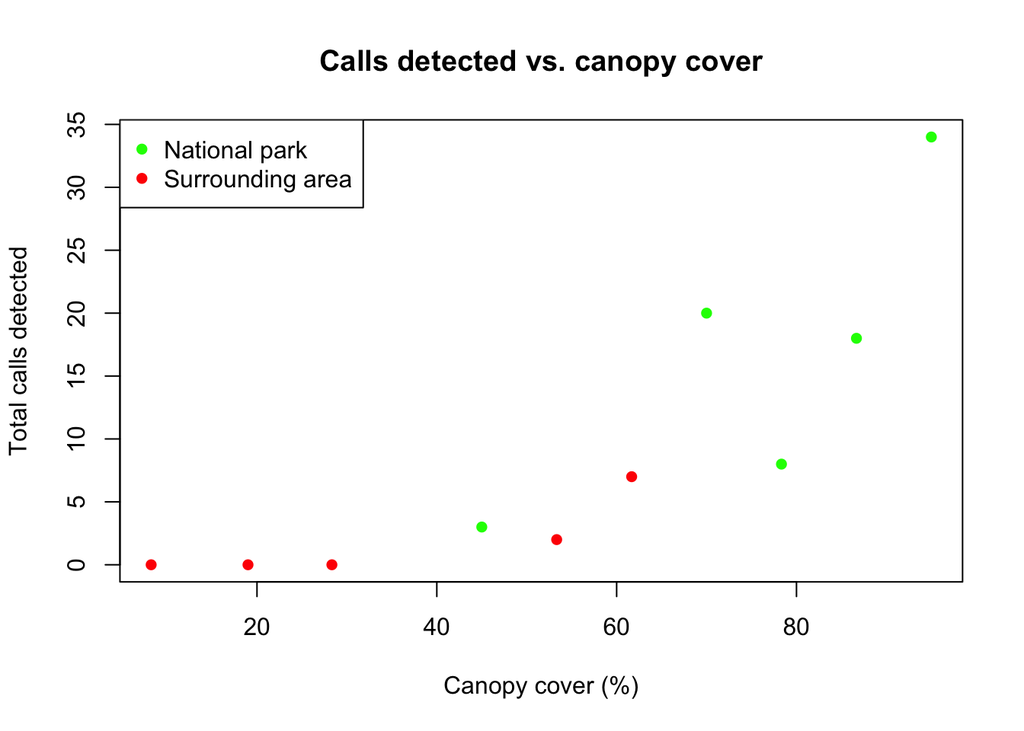

```r
# Basic scatter plot
plot.new() # clear any prior plots
plot(df_hornbill$canopy_cover, df_hornbill$detections, main = "Calls detected vs. canopy cover", xlab = "Canopy cover (%)", ylab = "Total calls detected", col = ifelse(df_hornbill$protection_status == "Yes", "green", "red"), pch = 16)

# Adding a legend
legend("topleft", legend = c("National park", "Surrounding area"), col = c("green", "red"), pch = 16)
```